About The Company & How Can This Help The Our Company?

IMDb (Internet Movie Database) well defined by it's name most renouned website for movie ratings; as their newly appointed data scientist i've built an end-to-end machine learning pipeline which pridicts the popularity of a movie on the bases of some given factors and by utlizing this we can introduce a Movie Recommendation System which could enhance the user experience and benefit industry stakeholders, including filmmakers, studios, distributors, and advertisers.

# Submission Form

[figure not shown]

```python
from IPython.display import Image
image_path = "/content/Submission Form ML .png"
Image(filename=image_path)
```

## Libirary

```python
import pandas as pd
from sklearn.model_selection import train_test_split,  RandomizedSearchCV
from sklearn.preprocessing import StandardScaler, OneHotEncoder
from sklearn.compose import ColumnTransformer
from sklearn.pipeline import Pipeline
from sklearn.linear_model import LogisticRegression
from sklearn.metrics import accuracy_score, precision_score, recall_score, f1_score, confusion_matrix
from sklearn.ensemble import RandomForestClassifier
import matplotlib.pyplot as plt
from scipy.stats import randint
```

## Dataset Loading [ https://www.kaggle.com/datasets/adriankiezun/imdb-dataset-2023?rvi=1 ]

```python
df = pd.read_csv("/content/imdb_data.csv")
df
```

|  | id | primaryTitle | originalTitle | isAdult | runtimeMinutes | genres | averageRating | numVotes | budget | gross | release_date | directors |
| --- | --- | --- | --- | --- | --- | --- | --- | --- | --- | --- | --- | --- |
| 0 | tt0035423 | Kate & Leopold | Kate & Leopold | 0 | 118 | Comedy,Fantasy,Romance | 6.4 | 87925 | 48000000 | 76019048.0 | December 11, 2001 | James Mangold |
| 1 | tt0065421 | The Aristocats | The AristoCats | 0 | 78 | Adventure,Animation,Comedy | 7.1 | 111758 | 4000000 | 35459543.0 | December 11, 1970 | Wolfgang Reitherman |
| 2 | tt0065938 | Kelly's Heroes | Kelly's Heroes | 0 | 144 | Adventure,Comedy,War | 7.6 | 52628 | 4000000 | 5200000.0 | January 1, 1970 | Brian G. Hutton |
| 3 | tt0066026 | M*A*S*H | M*A*S*H | 0 | 116 | Comedy,Drama,War | 7.4 | 75784 | 3500000 | 81600000.0 | January 25, 1970 | Robert Altman |
| 4 | tt0066206 | Patton | Patton | 0 | 172 | Biography,Drama,War | 7.9 | 106476 | 12000000 | 61749765.0 | February 4, 1970 | Franklin J. Schaffner |
| ... | ... | ... | ... | ... | ... | ... | ... | ... | ... | ... | ... | ... |
| 3343 | tt9770150 | Nomadland | Nomadland | 0 | 107 | Drama | 7.3 | 175977 | 5000000 | 39458207.0 | September 11, 2020 | Chloé Zhao |
| 3344 | tt9777666 | The Tomorrow War | The Tomorrow War | 0 | 138 | Action,Adventure,Drama | 6.6 | 220617 | 200000000 | 14400000.0 | June 30, 2021 | Chris McKay |
| 3345 | tt9784798 | Judas and the Black Messiah | Judas and the Black Messiah | 0 | 126 | Biography,Drama,History | 7.4 | 88568 | 26000000 | 7478009.0 | February 1, 2021 | Shaka King |
| 3346 | tt9844522 | Escape Room: Tournament of Champions | Escape Room: Tournament of Champions | 0 | 88 | Action,Adventure,Horror | 5.7 | 56955 | 15000000 | 65774490.0 | July 1, 2021 | Adam Robitel |
| 3347 | tt9893250 | I Care a Lot | I Care a Lot | 0 | 118 | Comedy,Crime,Drama | 6.4 | 141433 | 14000000 | 1351662.0 | September 12, 2020 | J Blakeson |

3348 rows × 12 columns

## Data Exploration

shape function helps you to know the shape of your dataset like here i have 3348 rows and 12 column.

```python
df.shape
```

```
(3348, 12)
```

```python
df.info()
```

```
<class 'pandas.core.frame.DataFrame'>
RangeIndex: 3348 entries, 0 to 3347
Data columns (total 12 columns):
 #   Column          Non-Null Count  Dtype
---  ------          --------------  -----
 0   id              3348 non-null   object
 1   primaryTitle    3348 non-null   object
 2   originalTitle   3348 non-null   object
 3   isAdult         3348 non-null   int64
 4   runtimeMinutes  3348 non-null   int64
 5   genres          3348 non-null   object
 6   averageRating   3348 non-null   float64
 7   numVotes        3348 non-null   int64
 8   budget          3348 non-null   int64
 9   gross           3297 non-null   float64
 10  release_date    3343 non-null   object
 11  directors       3348 non-null   object
dtypes: float64(2), int64(4), object(6)
memory usage: 314.0+ KB
```

To check if there is any missing values for each column

```python
missing_values = df.isnull().sum()
print(missing_values)
```

```
id                 0
primaryTitle       0
originalTitle      0
isAdult            0
runtimeMinutes     0
genres             0
averageRating      0
numVotes           0
budget             0
gross             51
release_date       5
directors          0
dtype: int64
```

Checking if there is any duplicate rows

```python
duplicate_rows = df.duplicated().sum()
print("Number of duplicate rows:", duplicate_rows)
```

```
Number of duplicate rows: 0
```

```python
df.describe()
```

|  | isAdult | runtimeMinutes | averageRating | numVotes | budget | gross |
| --- | --- | --- | --- | --- | --- | --- |
| count | 3348.0 | 3348.000000 | 3348.00000 | 3.348000e+03 | 3.348000e+03 | 3.297000e+03 |
| mean | 0.0 | 112.739845 | 6.73853 | 2.155492e+05 | 5.039280e+07 | 1.681599e+08 |
| std | 0.0 | 19.927703 | 0.88221 | 2.480211e+05 | 5.178614e+07 | 2.366507e+08 |
| min | 0.0 | 63.000000 | 1.00000 | 5.000400e+04 | 1.800000e+01 | 2.100000e+02 |
| 25% | 0.0 | 98.000000 | 6.20000 | 7.897700e+04 | 1.500000e+07 | 3.623022e+07 |
| 50% | 0.0 | 109.000000 | 6.80000 | 1.290400e+05 | 3.200000e+07 | 8.821516e+07 |
| 75% | 0.0 | 124.000000 | 7.30000 | 2.468495e+05 | 6.800000e+07 | 2.008117e+08 |
| max | 0.0 | 242.000000 | 9.30000 | 2.817283e+06 | 3.560000e+08 | 2.923706e+09 |

## Data Pre-Processing

Dropping un-wanted columns for a clean dataset & Filling missing values with median numbers

```python
df = df.drop(['id', 'primaryTitle', 'directors'], axis=1)
```

```python
df['gross'].fillna(df['gross'].median(), inplace=True)
df
```

|  | originalTitle | isAdult | runtimeMinutes | genres | averageRating | numVotes | budget | gross | release_date |
| --- | --- | --- | --- | --- | --- | --- | --- | --- | --- |
| 0 | Kate & Leopold | 0 | 118 | Comedy,Fantasy,Romance | 6.4 | 87925 | 48000000 | 76019048.0 | December 11, 2001 |
| 1 | The AristoCats | 0 | 78 | Adventure,Animation,Comedy | 7.1 | 111758 | 4000000 | 35459543.0 | December 11, 1970 |
| 2 | Kelly's Heroes | 0 | 144 | Adventure,Comedy,War | 7.6 | 52628 | 4000000 | 5200000.0 | January 1, 1970 |
| 3 | M*A*S*H | 0 | 116 | Comedy,Drama,War | 7.4 | 75784 | 3500000 | 81600000.0 | January 25, 1970 |
| 4 | Patton | 0 | 172 | Biography,Drama,War | 7.9 | 106476 | 12000000 | 61749765.0 | February 4, 1970 |
| ... | ... | ... | ... | ... | ... | ... | ... | ... | ... |
| 3343 | Nomadland | 0 | 107 | Drama | 7.3 | 175977 | 5000000 | 39458207.0 | September 11, 2020 |
| 3344 | The Tomorrow War | 0 | 138 | Action,Adventure,Drama | 6.6 | 220617 | 200000000 | 14400000.0 | June 30, 2021 |
| 3345 | Judas and the Black Messiah | 0 | 126 | Biography,Drama,History | 7.4 | 88568 | 26000000 | 7478009.0 | February 1, 2021 |
| 3346 | Escape Room: Tournament of Champions | 0 | 88 | Action,Adventure,Horror | 5.7 | 56955 | 15000000 | 65774490.0 | July 1, 2021 |
| 3347 | I Care a Lot | 0 | 118 | Comedy,Crime,Drama | 6.4 | 141433 | 14000000 | 1351662.0 | September 12, 2020 |

3348 rows × 9 columns

# Feature Engineering

Categorizing ratings

```python
df['rating_category'] = (df['averageRating'] >= 8.0).astype(int)
```

Selecting features and target variable

```python
x = df[['runtimeMinutes', 'numVotes', 'budget', 'gross', 'genres', 'release_date']]
y = df['rating_category']
```

# Data Spliting

spliting the data into train and test

```python
x_train, x_test, y_train, y_test = train_test_split(x, y, test_size=0.2, random_state=42)
```

# Scaling and Encoding within a Column Transformer

One-hot encoding the 'genres' column and scaling numerical features

```python
categorical_features = ['genres']
numerical_features = ['runtimeMinutes', 'numVotes', 'budget', 'gross']
```

```python
scaling = ColumnTransformer(
    transformers=[
        ('standard_scaling', StandardScaler(), numerical_features),
        ('one_hot-encoding', OneHotEncoder(handle_unknown='ignore'), categorical_features),
    ]
)
```

# Training the Model

Creating a pipeline that preprocesses and then appliying on the model

```python
lr = Pipeline(steps=[('scaling', scaling),
                           ('classifier', LogisticRegression(max_iter=1000))])
```

```python
lr.fit(x_train, y_train)
```

```
Pipeline(steps=[('scaling',
                 ColumnTransformer(transformers=[('standard_scaling',
                                                  StandardScaler(),
                                                  ['runtimeMinutes', 'numVotes',
                                                   'budget', 'gross']),
                                                 ('one_hot-encoding',
                                                  OneHotEncoder(handle_unknown='ignore'),
                                                  ['genres'])])),
                ('classifier', LogisticRegression(max_iter=1000))])
```

# Model Evaluation

```python
y_prid = lr.predict(x_test)
```

```python
print(f"Accuracy: {accuracy_score(y_test, y_prid)}")
print(f"Precision: {precision_score(y_test, y_prid)}")
conf_matrix = confusion_matrix(y_test, y_prid)
```

```
Accuracy: 0.9641791044776119
Precision: 0.84375
```

Visualizing our confusion matrix

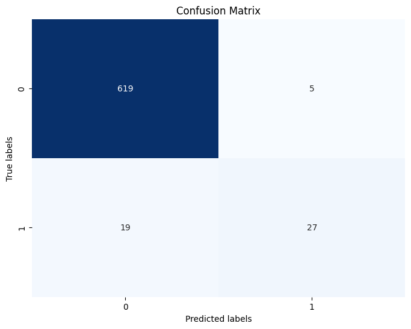

```python
plt.figure(figsize=(8, 6))
sns.heatmap(conf_matrix, annot=True, fmt='d', cmap='Blues', cbar=False)
plt.xlabel('Predicted labels')
plt.ylabel('True labels')
plt.title('Confusion Matrix')
plt.show()
```

Trying To Improve My Results With RandomForrestClassifier and Hyperp

Creating the pipeline for RFC

```python
pipeline = Pipeline([
    ('preprocessing', ColumnTransformer([
        ('numerical', StandardScaler(), numerical_features),
        ('categorical', OneHotEncoder(handle_unknown='ignore'), categorical_features)
    ])),
    ('model', RandomForestClassifier(n_estimators=100, max_depth=None, random_state=42))
])
```

```python
pipeline.fit(x_train, y_train)
```

```
Pipeline(steps=[('preprocessing',
                 ColumnTransformer(transformers=[('numerical', StandardScaler(),
                                                  ['runtimeMinutes', 'numVotes',
                                                   'budget', 'gross']),
                                                 ('categorical',
                                                  OneHotEncoder(handle_unknown='ignore'),
                                                  ['genres'])])),
                ('model', RandomForestClassifier(random_state=42))])
```

Hyperp training to select the best machine learning algorithm and tune its hyper- parameters.

Defining hyperparameters for randomized search

```python
hyperp = {
    'model__n_estimators': randint(100, 500),
    'model__max_depth': [None] + list(randint(5, 50).rvs(10)),
    'model__min_samples_split': randint(2, 20),
    'model__min_samples_leaf': randint(1, 20)
}
```

Performing randomized-search for hyperparameter tuning and getting the best model from randomized search

```python
rndm = RandomizedSearchCV(pipeline, param_distributions=hyperp, n_iter=20, cv=5, scoring='accuracy', random_state=42)
rndm.fit(x_train, y_train)

best_model = rndm.best_estimator_
```

Predicting for the test set

```python
y_prid = pipeline.predict(x_test)
```

Evaluating RandomForrestClassifier

```python
accuracy = accuracy_score(y_test, y_prid)
precision = precision_score(y_test, y_prid)
recall = recall_score(y_test, y_prid)
f1 = f1_score(y_test, y_prid)

print(f"Best Parameters: {rndm.best_params_}")
print(f"Accuracy: {accuracy}")
print(f"Precision: {precision}")
print(f"Recall: {recall}")
print(f"F1 Score: {f1}")
```

```
Best Parameters: {'model__max_depth': 17, 'model__min_samples_leaf': 1, 'model__min_samples_split': 13, 'model__n_estimators': 413}
Accuracy: 0.9552238805970149
Precision: 0.8076923076923077
Recall: 0.45652173913043476
F1 Score: 0.5833333333333333
```

# Conclusion

Over-all this pipeline is performing well with both training models, However the scores of logistic regression is better still RFC is not bad. This Model pridicts the popularity of movies and company can use this to enhance the user experience and introduce some wall of fame and showcase the best picks.

Counting down some strengths:

1. Flexiblity to dataset: this is capable to accommodate different types of models and preprocessing techniques.
2. Performance and interpretability: Both RFC and Logistic Regression model achieve high accuracy and precision on this test set, indicating their effectiveness

Counting down some limitations:

1. Scalability : with some extremely big dataset, the pipeline's performance may degrade. more advanced tuning will be required and will take time.
2. Complexity and FeatureEng. RFC can be complex: RFc is complicated in coparesion to logistic regression and the effectiveness of this modeel heavily relies on the selection and enginering of features.

Recomendations:

Continious enhancement as there are new movies and new rating the dataset should be upgraded and updated.

Reference: [ https://stackoverflow.com ]